# A4 - Anàlisi de variància

Salvador Sanchis Beneseit

January 9, 2022

## 1. Introducció

## 2. Lectura del fitxer i preparació de les dades

```r
adult <- read.csv("~/DS21:22/advanced statistics/PAC/4/CensusIncomedata.txt", sep="")
```

### 2.1 Preparació de les dades

Eliminem espais en blanc i convertim text a factors:

```r
cols <- c('workclass', 'marital_status', 'occupation', 'race', 'sex')
adult[cols] <- lapply(adult[cols], trimws)
adult[cols] <- lapply(adult[cols], factor)
```

Modifiquem el nom de la columna ‘sex’:

```r
colnames(adult)[7] <- 'gender'
```

En l’histograma de la variable ‘income’ hi veiem una asimetria (cua a l’esquerra):

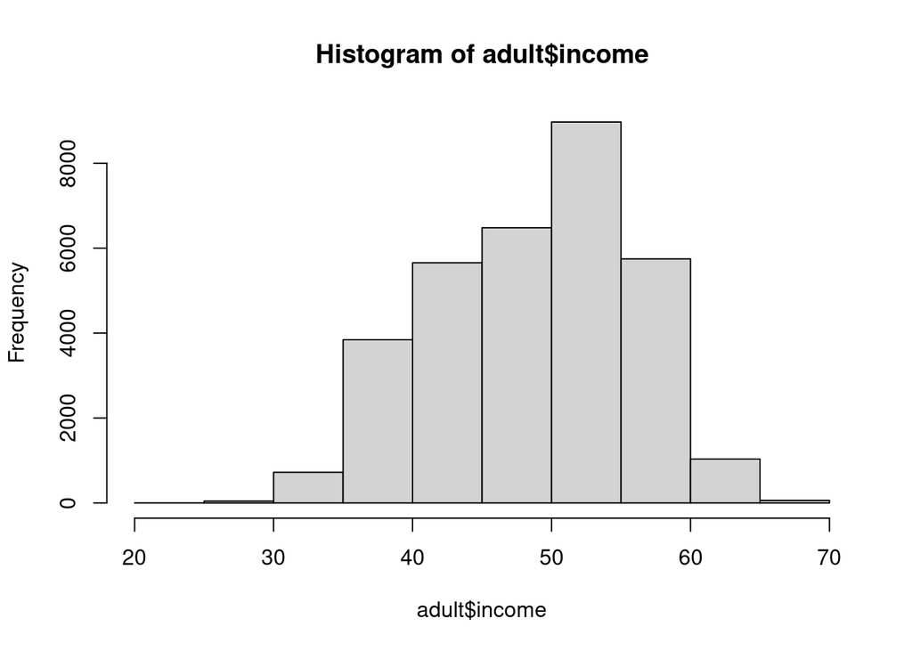

```r
hist(adult$income)
```

En el gràfic Q-Q hi veiem una desviació de la normalitat en la superposició dels punts sobre la línia:

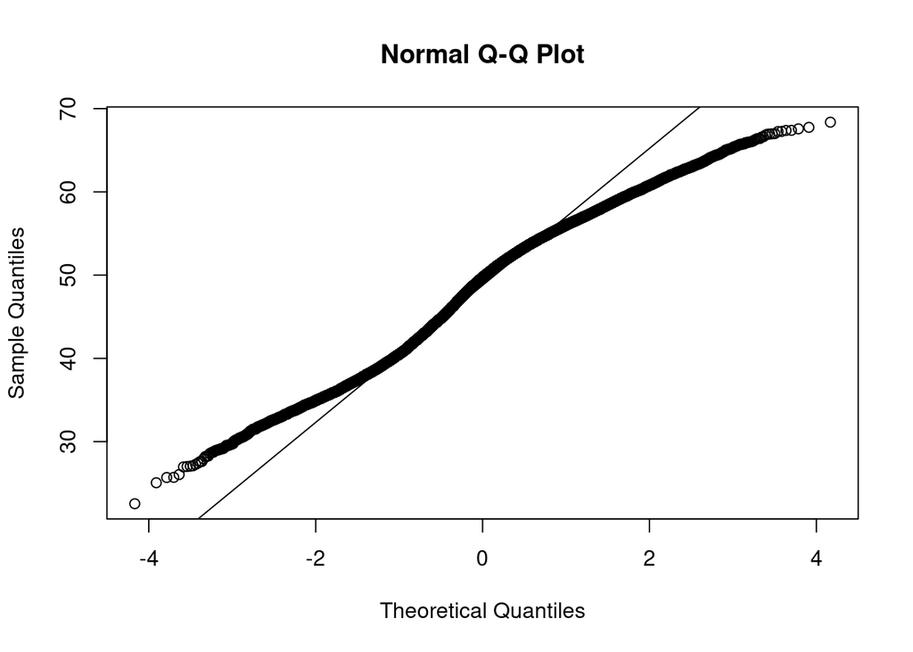

```r
qqnorm(adult$income)
qqline(adult$income)
```

I finalment, el valor-p del test de Lilliefors ens confirma que la variable ‘income’ no es distribueix segons una distribució normal:

```r
library(nortest)
lillie.test(adult$income)
```

```
##
##  Lilliefors (Kolmogorov-Smirnov) normality test
##
## data:  adult$income
## D = 0.061672, p-value < 2.2e-16
```

Creem la nova variable ‘Less50’:

```r
adult$Less50 <- cut(adult$income, breaks=c(0,50,70), right = FALSE, labels = c(1, 0))
```

### 2.2 Anàlisi visual

Els diagrames de caixa ens indiquen que el salari és superior en el cas dels homes:

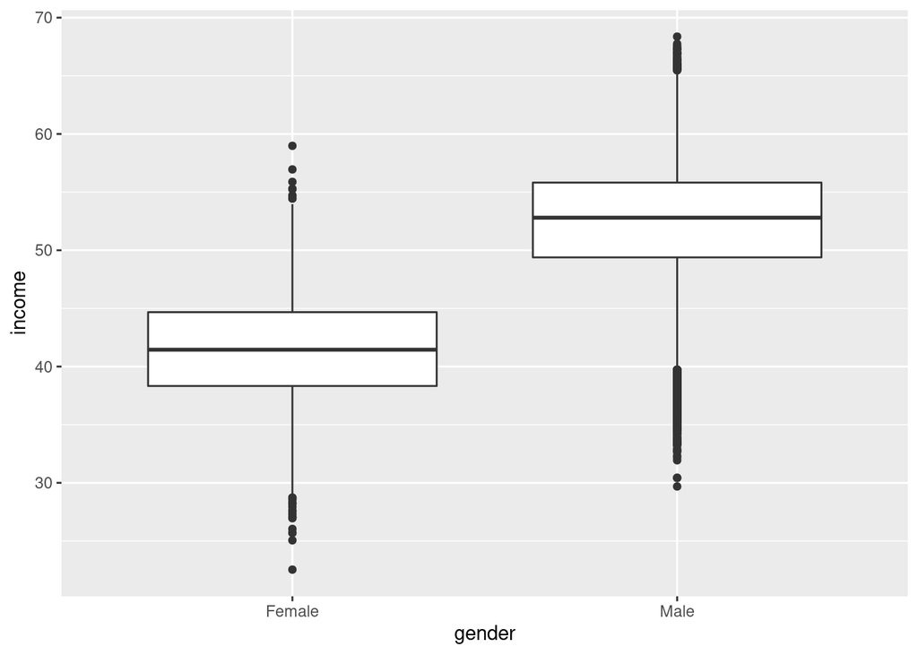

```r
library(ggplot2)
ggplot(aes(y=income, x=gender), data=adult) + geom_boxplot()
```

També veiem diferències pel que fa a la raça, on els salaris més alts es troben en el sector de raça blanca:

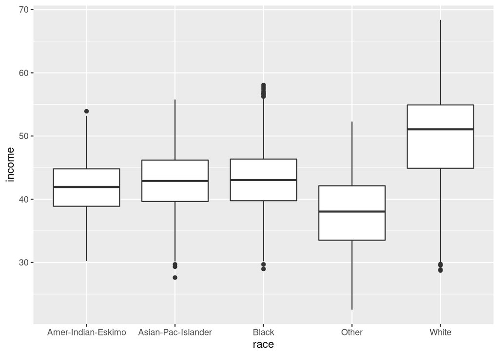

```r
ggplot(aes(y=income, x=race), data=adult) + geom_boxplot()
```

Pel que fa al perfil laboral, els funcionaris semblen tenir salaris més alts:

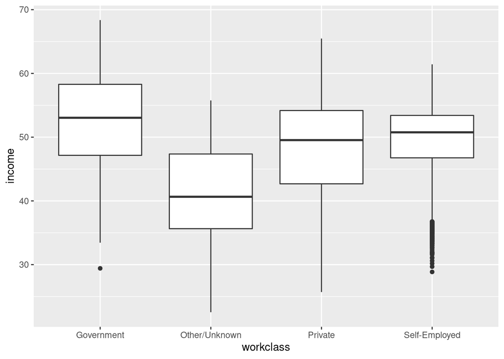

```r
ggplot(aes(y=income, x=workclass), data=adult) + geom_boxplot()
```

I l’estat civil que sembla acaparar salaris més alts és casat:

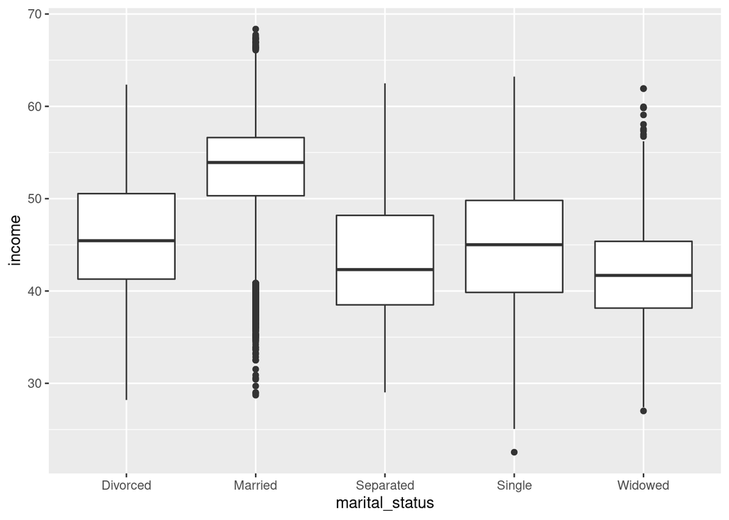

```r
ggplot(aes(y=income, x=marital_status), data=adult) + geom_boxplot()
```

Pel que fa a la tipologia, els salaris més alts es concentren en les categories blue-collar, white-collar i professional:

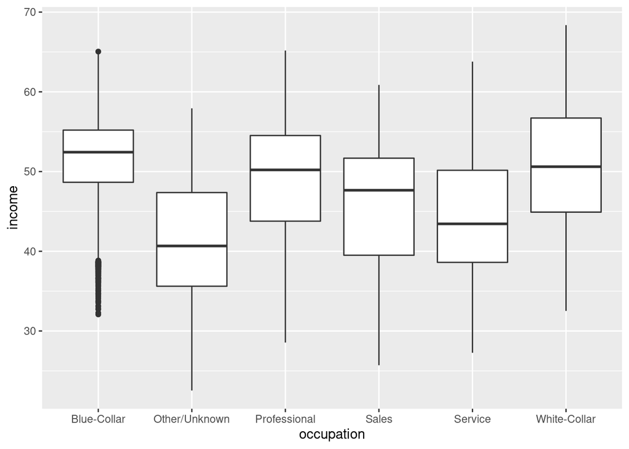

```r
ggplot(aes(y=income, x=occupation), data=adult) + geom_boxplot()
```

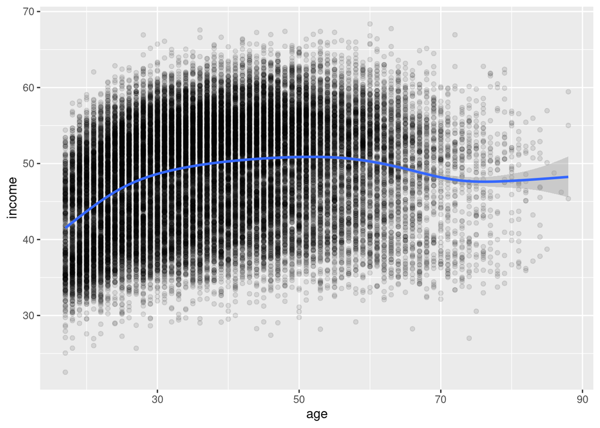

```r
ageplot <- adult[!(adult$age==90),]
ggplot(aes(x =age, y = income), data = ageplot) + geom_point(alpha=.1) +
  geom_smooth()
```

La variable hores de treball ens mostra els salaris més alts entorn les 50 hores setmanals. Hi ha un augment addicional en la zona de les 90+ hores setmanals, però amb un marge d’error també superior, ja que es tracta de pocs casos. (Hem eliminat 83 registres amb un valor de 99 hores setmanals treballades):

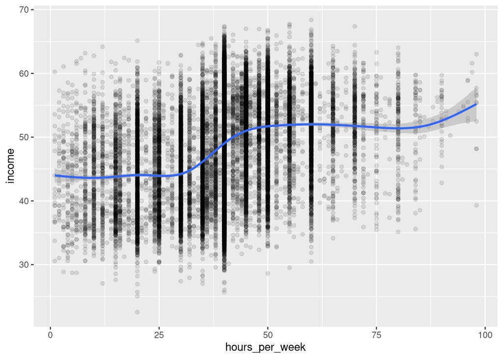

```r
hoursplot <- adult[!(adult$hours_per_week==99),]
ggplot(aes(x =hours_per_week, y = income), data = hoursplot) + geom_point(alpha=.1) + geom_smooth()
```

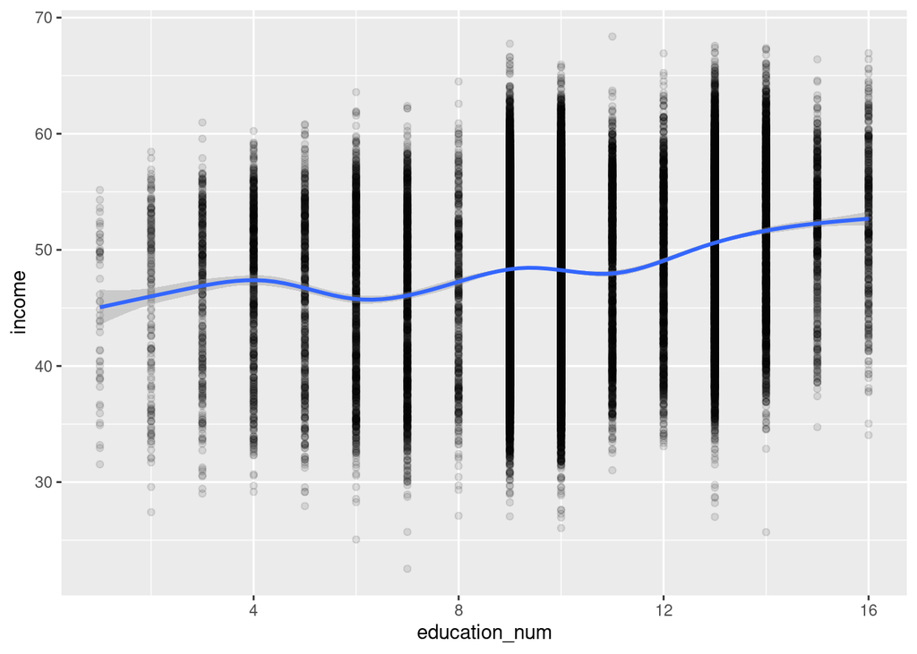

```r
ggplot(aes(x =education_num, y = income), data = adult) + geom_point(alpha=.1) + geom_smooth()
```

## 3. Estadística inferencial

### 3.1 Contrastos d’hipòtesi

#### 3.1.1. Hipòtesi nul·la i alternativa (pel gènere i pel cas racial)

Pel gènere:  
H<sub>0</sub> : 𝛍<sub>men_income</sub> = 𝛍<sub>women_income</sub>

H<sub>1</sub> : 𝛍<sub>men_income</sub> > 𝛍<sub>women_income</sub>

La hipòtesi nul·la és que, de mitjana, els homes cobren igual que les dones.

La hipòtesi alternativa és que la mitjana de salari dels homes és superior a la mitjana de salari de les dones.

Pel que fa al cas racial:

H<sub>0</sub> : 𝛍<sub>1</sub> - 𝛍<sub>2 =</sub> 6.45k€

H<sub>0</sub> : 𝛍<sub>1</sub> - 𝛍<sub>2 ></sub> 6.45k€

on 𝛍<sub>1</sub> denota la mitjana de salari de la gent blanca i 𝛍<sub>2</sub> la mitjana de salari de la gent negra.

#### 3.1.2. Justificació del test a aplicar (pel gènere i pel cas racial)

Agrupem els casos segons els factors:

```r
men_s <- adult$income[adult$gender=="Male"]
women_s <- adult$income[adult$gender=="Female"]

white_s <- adult$income[adult$race=="White"]
black_s <- adult$income[adult$race=="Black"]
```

Per les dues hipòtesis, assumim normalitat segons el teorema del límit central i en ambdós casos fem un contrast d’hipòtesi de dues mostres sobre la mitjana.

Primer comparem variàncies:

```r
var.test(men_s, women_s)
```

```
##
##  F test to compare two variances
##
## data:  men_s and women_s
## F = 1.331, num df = 21788, denom df = 10770, p-value < 2.2e-16
## alternative hypothesis: true ratio of variances is not equal to 1
## 95 percent confidence interval:
##  1.288172 1.375099
## sample estimates:
## ratio of variances
##           1.331048
```

```r
var.test(white_s, black_s)
```

```
##
##  F test to compare two variances
##
## data:  white_s and black_s
## F = 2.1516, num df = 27814, denom df = 3123, p-value < 2.2e-16
## alternative hypothesis: true ratio of variances is not equal to 1
## 95 percent confidence interval:
##  2.040794 2.265905
## sample estimates:
## ratio of variances
##           2.151597
```

En ambdós casos la variància és desconeguda i diferent, i per tant farem un test sobre mitjana de dues mostres independents amb variància desconeguda i diferent.

#### 3.1.3. Aplicació, interpretació i comprovació del test (pel gènere i pel cas racial)

Definim la funció per a realitzar el test:

```r
ind_ttest <- function(x,y,d){
x1 <-mean(x)
x2 <-mean(y)
var_1 <- var(x)
var_2 <- var(y)
n1 <- length(x)
n2 <- length(y)
sn_1 <- var_1 / n1
sn_2 <- var_2 / n2
estadístic_de_contrast <- (x1-x2-d) / sqrt((var_1/n1)+(var_2/n2))
graus_de_llibertat <- ((sn_1 + sn_2)^2) / (((sn_1^2)/(n1-1))+((sn_2^2)/(n2-1)))
valor_p <- pt(estadístic_de_contrast, graus_de_llibertat, lower.tail = FALSE)
valor_crític <- qt(.95, df= graus_de_llibertat)
return(data.frame(estadístic_de_contrast, graus_de_llibertat, valor_crític, valor_p)) }
```

Apliquem el test pel cas de gènere:

```r
ind_ttest(men_s, women_s, 0)
```

```
##   estadístic_de_contrast graus_de_llibertat valor_crític valor_p
## 1               194.1064           24386.74     1.644916       0
```

El resultat del test, amb un valor observat de 194.11, per sobre del valor crític de 1.64, i un valor p 0, ens indica que cal rebutjar la hipòtesi nul·la i acceptar la hipòtesi alternativa segons la qual els homes cobren més que les dones.

Comprovem els resultats:

```r
t.test(men_s, women_s, alternative = "greater", var.equal = FALSE)
```

```
##
##  Welch Two Sample t-test
##
## data:  men_s and women_s
## t = 194.11, df = 24387, p-value < 2.2e-16
## alternative hypothesis: true difference in means is greater than 0
## 95 percent confidence interval:
##  10.70369      Inf
## sample estimates:
## mean of x mean of y
##  52.32476  41.52959
```

Apliquem el mateix test pel cas racial, amb una diferència de mitjana de 6450€:

```r
ind_ttest(white_s, black_s, 6.45)
```

```
##   estadístic_de_contrast graus_de_llibertat valor_crític    valor_p
## 1               2.037051           4783.375     1.645172 0.02084993
```

Amb un estadístic de contrast de 2.04, just per sobre del valor crític 1.64, i un valor p de 0.02, per sota del llindar de 0.05, podem rebutjar la hipòtesi nul·la i concloure que les persones de raça blanca cobren més de 6450€ per sobre del salari de les persones de raça negra.

Comprovem els resultats:

```r
t.test(white_s, black_s, alternative = "greater", mu= 6.45, var.equal = FALSE)
```

```
##
##  Welch Two Sample t-test
##
## data:  white_s and black_s
## t = 2.0371, df = 4783.4, p-value = 0.02085
## alternative hypothesis: true difference in means is greater than 6.45
## 95 percent confidence interval:
##  6.48668     Inf
## sample estimates:
## mean of x mean of y
##  49.78750  43.14683
```

## 4. Model de regressió lineal

### 4.1. Estimació de models

```r
linear_1 <- lm(income~age+education_num+hours_per_week+gender, data = adult)
summary(linear_1)
```

```
##
## Call:
## lm(formula = income ~ age + education_num + hours_per_week +
##     gender, data = adult)
##
## Residuals:
##      Min       1Q   Median       3Q      Max
## -21.4319  -2.7990   0.2859   3.1140  17.0719
##
## Coefficients:
##                 Estimate Std. Error t value Pr(>|t|)
## (Intercept)    31.315777   0.139088  225.15   <2e-16 ***
## age             0.082515   0.001858   44.41   <2e-16 ***
## education_num   0.446817   0.009913   45.07   <2e-16 ***
## hours_per_week  0.073834   0.002123   34.77   <2e-16 ***
## genderMale     10.108404   0.055211  183.09   <2e-16 ***
## ---
## Signif. codes:  0 '***' 0.001 '**' 0.01 '*' 0.05 '.' 0.1 ' ' 1
##
## Residual standard error: 4.548 on 32555 degrees of freedom
## Multiple R-squared:  0.5892, Adjusted R-squared:  0.5891
## F-statistic: 1.167e+04 on 4 and 32555 DF,  p-value: < 2.2e-16
```

```r
linear_2 <- lm(income~age+education_num+hours_per_week+gender+race, data = adult)
summary(linear_2)
```

```
##
## Call:
## lm(formula = income ~ age + education_num + hours_per_week +
##     gender + race, data = adult)
##
## Residuals:
##     Min      1Q  Median      3Q     Max
## -15.264  -2.817   0.008   2.775  16.073
##
## Coefficients:
##                         Estimate Std. Error t value Pr(>|t|)
## (Intercept)            26.183312   0.260285 100.595   <2e-16 ***
## age                     0.078247   0.001673  46.768   <2e-16 ***
## education_num           0.419036   0.008971  46.710   <2e-16 ***
## hours_per_week          0.071274   0.001911  37.301   <2e-16 ***
## genderMale              9.780936   0.049976 195.712   <2e-16 ***
## raceAsian-Pac-Islander -0.214519   0.264932  -0.810    0.418
## raceBlack               2.382315   0.243405   9.787   <2e-16 ***
## raceOther              -3.562672   0.340136 -10.474   <2e-16 ***
## raceWhite               6.681488   0.233491  28.616   <2e-16 ***
## ---
## Signif. codes:  0 '***' 0.001 '**' 0.01 '*' 0.05 '.' 0.1 ' ' 1
##
## Residual standard error: 4.092 on 32551 degrees of freedom
## Multiple R-squared:  0.6674, Adjusted R-squared:  0.6674
## F-statistic:  8166 on 8 and 32551 DF,  p-value: < 2.2e-16
```

### 4.2. Interpretació dels models

Trobem relacions significatives per a totes les variables explicatives d’ambdós models (tots els valors p<2.2e-16), amb l’excepció del factor “Asian-Pac_Islander” de la variable race(p=0.418).

Les variables que contribueixen en major grau al model són les variables gènere i raça. Concretament, el factor ‘Male’ de la variable gènere mostra una alta relació positiva amb la variable dependent income. Pel que fa a la variable raça, els factors ‘black’ i, especialment, ‘white, també mostren una relació lineal positiva, i el factor ’other’ mostra una relació negativa.

El coeficient de determinació del primer model és de R<sup>2</sup>=0.5891, i el del segon model és de R<sup>2</sup>=0.6674. Per tant, podem afirmar que hi ha hagut una millora del model quan hem introduït la variable raça.

### 4.3. Anàlisi de residus

La ditribució dels residus del model 2 és gairebé perfectament simètrica entorn un valor mitjà de 0 (min -15, max 16, 1Q -2.8, 3Q 2.7) i això indica una bona adequació del model.

En un primer gràfic de residus contra valors ajustats veiem un patró força arbitrari, i per tant no sospitem que hi hagi un problema d’heterocedasticitat i assumim una variància constant en els errors del model.

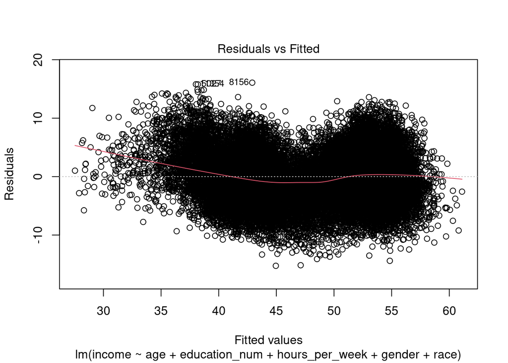

```r
plot(linear_2, which = 1)
```

En un gràfic Q-Q veiem que les dades s’justen bé a una distribució normal:

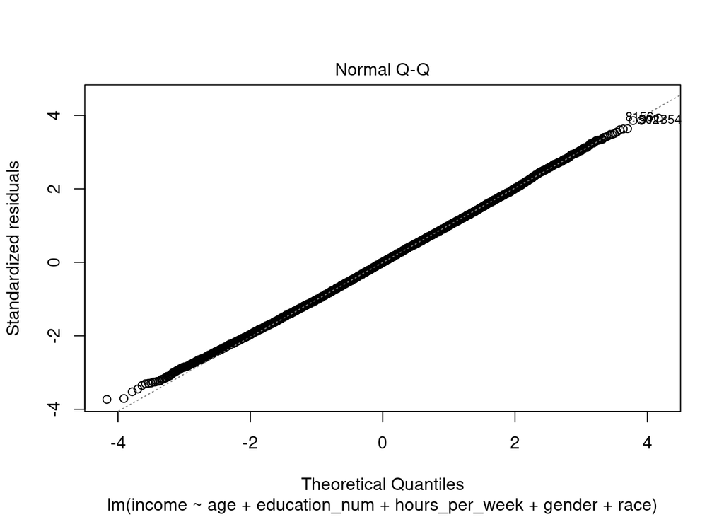

```r
plot(linear_2, which = 2)
```

### 4.4. Predicció

Aquesta és la predicció del model per a un seguit de dades, amb un interval de confiança del 95%:

```r
pre <- data.frame(age=24, education_num= 4, hours_per_week=40, gender='Female', race='Black')
predict(linear_2, pre, interval = "confidence")
```

```
##        fit    lwr      upr
## 1 34.97064 34.785 35.15627
```

## 5. Regressió logística

### 5.1. Generació de conjunts d’entrenament i de test

Primer de tot, reorganitzem l’ordre dels factors de les variables categòriques, ja que això ens serà necessari per dissenyar més endavant el model de regressió logística:

```r
adult <- within(adult, workclass <- relevel(workclass, ref = 'Private'))
adult <- within(adult, marital_status <- relevel(marital_status, ref = 'Married'))
adult <- within(adult, race <- relevel(race, ref = 'White'))
adult <- within(adult, gender <- relevel(gender, ref = 'Male'))
adult <- within(adult, Less50 <- relevel(Less50, ref = '0'))
```

Generem els conjunts d’entrenament i test:

```r
set.seed(1234)
div <- sample(2, nrow(adult), replace = T, prob = c(0.8, 0.2))
train <- adult[div==1,]
test <- adult[div==2,]
```

### 5.2. Model predictiu

Entrenem el model de regressió logística amb el conjunt ‘train’:

```r
log_1 <- glm(Less50 ~ age+workclass+education_num+marital_status+occupation+race+gender+hours_per_week, data = train, family = 'binomial')
summary(log_1)
```

```
##
## Call:
## glm(formula = Less50 ~ age + workclass + education_num + marital_status +
##     occupation + race + gender + hours_per_week, family = "binomial",
##     data = train)
##
## Deviance Residuals:
##     Min       1Q   Median       3Q      Max
## -4.5048  -0.1853   0.0003   0.0814   3.1469
##
## Coefficients:
##                          Estimate Std. Error z value Pr(>|z|)
## (Intercept)              0.187761   0.179582   1.046  0.29577
## age                     -0.026909   0.002511 -10.717  < 2e-16 ***
## workclassGovernment     -3.503788   0.119355 -29.356  < 2e-16 ***
## workclassOther/Unknown   2.276538   0.989021   2.302  0.02135 *
## workclassSelf-Employed   2.510501   0.085424  29.389  < 2e-16 ***
## education_num           -0.282361   0.012351 -22.861  < 2e-16 ***
## marital_statusDivorced   2.705129   0.091791  29.470  < 2e-16 ***
## marital_statusSeparated  3.688918   0.174055  21.194  < 2e-16 ***
## marital_statusSingle     3.474572   0.082700  42.014  < 2e-16 ***
## marital_statusWidowed    2.974279   0.235701  12.619  < 2e-16 ***
## occupationOther/Unknown  2.975891   0.987269   3.014  0.00258 **
## occupationProfessional   1.779379   0.107481  16.555  < 2e-16 ***
## occupationSales          2.562621   0.091038  28.149  < 2e-16 ***
## occupationService        2.637406   0.092617  28.476  < 2e-16 ***
## occupationWhite-Collar  -1.716526   0.111563 -15.386  < 2e-16 ***
## raceAmer-Indian-Eskimo   7.857399   0.523827  15.000  < 2e-16 ***
## raceAsian-Pac-Islander   7.809475   0.218341  35.767  < 2e-16 ***
## raceBlack                6.579412   0.156448  42.055  < 2e-16 ***
## raceOther                9.494591   0.871939  10.889  < 2e-16 ***
## genderFemale             8.465626   0.159048  53.227  < 2e-16 ***
## hours_per_week          -0.026270   0.002265 -11.597  < 2e-16 ***
## ---
## Signif. codes:  0 '***' 0.001 '**' 0.01 '*' 0.05 '.' 0.1 ' ' 1
##
## (Dispersion parameter for binomial family taken to be 1)
##
##     Null deviance: 36103.3  on 26053  degrees of freedom
## Residual deviance:  9236.7  on 26033  degrees of freedom
## AIC: 9278.7
##
## Number of Fisher Scoring iterations: 8
```

### 5.3. Interpretació

Pel que fa al perfil de treball, ser funcionari té un efecte negatiu 3.5 vegades major de tenir un salari baix respecte a treballar en el sector privat, mentre que els sectors ‘autònoms’ i ‘desconegut’ tenen uns efectes positius de 2.5 i 2.2 respectivament.

Pel que fa a l’estat civil, prenent l’estat de casat com a referència, els estats ‘divorciat’, ‘separat’, ‘solter’ i ‘vidu’ tenen tots efectes positius sobre la possibilitat d’un salari baix, amb magnituds de 2.7, 3.6, 3.4 i 2.9 respectivament.

Pel que fa a la tipologia de treball, i respecte a la categoria ‘Blue Collar’, les categories ‘desconegut’, ‘professional’, ‘vendes’ i ‘serveis’ tenen efectes positius sobre la possibilitat d’un salari baix, amb magnituds de 2.9, 1.77, 2.56, 2.63, mentre que la categoria ‘White-collar’ disminueix la possibilitat d’un salari baix respecte a ‘Blue-collar’ amb una magnitud de 1.71.

Pel que fa a la raça, i respecte a la raça blanca, amerindis, asiàtics, negres i altres tenen relacions positives amb la possibilitat d’un salari baix, amb magnituds de 7.86, 7.81, 6.58 i 9.49 respectivament. De forma similar, les dones tenen un 8.47 més de possibilitats de tenir un salari baix respecte als homes.

### 5.4. Matriu de confusió

Generem una predicció sobre el conjunt test:

```r
predict_Less50 <- predict(log_1, newdata = test, type = 'response')
head(predict_Less50)
```

```
##           5          14          16          26          28          29
## 0.718566108 0.940704282 0.884872033 0.391502852 0.010814873 0.008811539
```

Definim un llindar de 0.5 per les prediccions del model:

```r
pred_bin <- ifelse(predict_Less50>0.5, 1, 0)
test$L50pred <- as.factor(pred_bin)
```

Generem la matriu de confusió:

```r
library(caret)
confusionMatrix(data = test$L50pred, reference = test$Less50, positive = '1')
```

```
## Confusion Matrix and Statistics
##
##           Reference
## Prediction    0    1
##          0 2917  292
##          1  198 3099
##
##                Accuracy : 0.9247
##                  95% CI : (0.918, 0.931)
##     No Information Rate : 0.5212
##     P-Value [Acc > NIR] : < 2.2e-16
##
##                   Kappa : 0.8493
##
##  Mcnemar's Test P-Value : 2.654e-05
##
##             Sensitivity : 0.9139
##             Specificity : 0.9364
##          Pos Pred Value : 0.9399
##          Neg Pred Value : 0.9090
##              Prevalence : 0.5212
##          Detection Rate : 0.4763
##    Detection Prevalence : 0.5068
##       Balanced Accuracy : 0.9252
##
##        'Positive' Class : 1
##
```

### 5.5. Predicció

Calculem manualment un primer cas:

```r
coefficients_calc_1 <- 0.187761+(20*-0.026909)+2.510501+(3*-0.282361)+3.474572+1.779379+(25*-0.026270)

Probability_1 = 1 / (1 + exp(-coefficients_calc_1))
Probability_1
```

```
## [1] 0.9972957
```

Contrastem el resultat:

```r
income_1 <- data.frame(age=20, workclass='Self-Employed', education_num=3, marital_status='Single', occupation='Professional', race='White', gender='Male', hours_per_week=25)
predict(log_1, income_1, type = 'response')
```

```
##         1
## 0.9972957
```

Calculem manualment un segon cas:

```r
coefficients_calc_2 <- 0.187761+(60*-0.026909)-3.503788+(15*-0.282361)-1.716526+6.579412+(35*-0.026270)
Probability_2 = 1 / (1 + exp(-coefficients_calc_2))
Probability_2
```

```
## [1] 0.005364645
```

Contrastem el resultat:

```r
income_2 <- data.frame(age=60, workclass='Government', education_num=15, marital_status='Married', occupation='White-Collar', race='Black', gender='Male', hours_per_week=35)
predict(log_1, income_2, type = 'response')
```

```
##           1
## 0.005364577
```

## 6. Anàlisi de la variància (ANOVA) d’un factor

### 6.1. Anàlisi de la variància (ANOVA) d’un factor

Recuperem un gràfic que ja hem presentat en l’apartat 2.2:

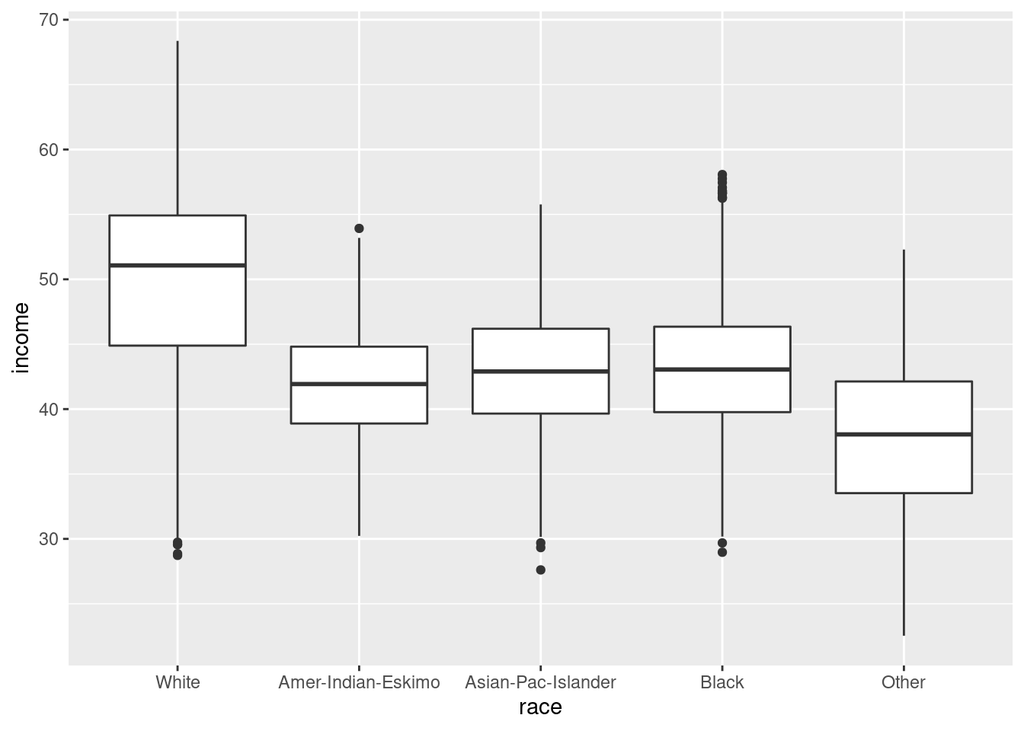

```r
ggplot(aes(y=income, x=race), data=adult) + geom_boxplot()
```

En el gràfic observem que sembla haver-hi un efecte del factor raça, amb els individus de raça blanca que obtenen una mitjana de salaris més alta que la resta.

### 6.2. Model ANOVA

#### 6.2.1. Formuleu el model

L’ANOVA planteja si hi ha diferències entre les mitjanes que s’obtenen de la variable dependent en diversos nivells (factors) de la variable independent. Encara que es prenen les mitjanes com a referència, el que l’ANOVA calcula és la diferència de variància, ja que és necessari poder detectar si dues mitjanes similars provenen de factors amb una distribució mot diferent l’una de l’altra. Prenent com a referència global la mitjana de tota la mostra, en aquest cas el que el model planteja és si hi ha diferències entre les mitjanes de salari que s’obtenen per a cada grup racial, és a dir, si totes són iguals, o si n’hi ha dues que són significativament diferents entre elles.

#### 6.2.2. Hipòtesi nul·la i alternativa

H<sub>0</sub> : 𝛍<sub>white</sub> = 𝛍<sub>black</sub> = 𝛍<sub>black … =</sub> 𝛍<sub>other</sub> = 𝛍

H<sub>1</sub> : 𝛍<sub>i</sub> > 𝛍<sub>j</sub> per a algun i ≠ j

#### 6.2.3. Estimeu la significació del factor grup racial

Obtenim la taula ANOVA:

```r
resultat_1 <- lm(income~race, data = adult)
table_1 <- anova(resultat_1)
table_1
```

```
## Analysis of Variance Table
##
## Response: income
##              Df  Sum Sq Mean Sq F value    Pr(>F)
## race          4  211909   52977  1208.4 < 2.2e-16 ***
## Residuals 32555 1427206      44
## ---
## Signif. codes:  0 '***' 0.001 '**' 0.01 '*' 0.05 '.' 0.1 ' ' 1
```

Calculem la variabilitat explicada per la variable ‘race’, que resulta ser d’un 13%:

```r
variabilitat <- 211909/(211909+1427206)
variabilitat
```

```
## [1] 0.1292826
```

#### 6.2.4. Estimeu els efectes dels nivells del factor

Calculem els efectes de cada factor separadament, confirmant que només el nivell ‘white’ contribueix positivament a l’increment del salari:

```r
resultat_2 <- aov(income~race, data = adult)
model.tables(resultat_2, type='effects')
```

```
## Tables of effects
##
##  race
##         White Amer-Indian-Eskimo Asian-Pac-Islander    Black  Other
##         1.034             -6.867             -5.855   -5.607 -11.15
## rep 27815.000            311.000           1039.000 3124.000 271.00
```

#### 6.2.5. Realitzeu els contrastos dos-a-dos

Realitzem un test LSD, on veiem que hi ha diferències significatives entre el grup blancs i la resta dels grups, i també del grup ‘altres’ envers la resta. Els resultats ens mostren 4 subgrups, amb diferències significatives entre cada subgrup (els subgrups s’identifiquen amb les lletres a, b, c i d en els resultats del test):

```r
library(agricolae)
LSD.test(resultat_1, 'race', group=T, p.adj='bonferroni', console=T)
```

```
##
## Study: resultat_1 ~ "race"
##
## LSD t Test for income
## P value adjustment method: bonferroni
##
## Mean Square Error:  43.83985
##
## race,  means and individual ( 95 %) CI
##
##                      income      std     r      LCL      UCL   Min   Max
## Amer-Indian-Eskimo 41.88682 4.498709   311 41.15092 42.62272 30.23 53.92
## Asian-Pac-Islander 42.89898 4.805233  1039 42.49636 43.30160 27.61 55.77
## Black              43.14683 4.694985  3124 42.91464 43.37902 28.97 58.07
## Other              37.60339 5.766821   271 36.81505 38.39174 22.54 52.29
## White              49.78750 6.886755 27815 49.70969 49.86532 28.73 68.37
##
## Alpha: 0.05 ; DF Error: 32555
## Critical Value of t: 2.807225
##
## Groups according to probability of means differences and alpha level( 0.05 )
##
## Treatments with the same letter are not significantly different.
##
##                      income groups
## White              49.78750      a
## Black              43.14683      b
## Asian-Pac-Islander 42.89898     bc
## Amer-Indian-Eskimo 41.88682      c
## Other              37.60339      d
```

Realitzem un segon test que confirma els resultats, on hi podem veure els nivells de significació de les diferències entre grups:

```r
library(stats)
pairwise.t.test(adult$income, adult$race, p.adj='bonferroni')
```

```
##
##  Pairwise comparisons using t tests with pooled SD
##
## data:  adult$income and adult$race
##
##                    White   Amer-Indian-Eskimo Asian-Pac-Islander Black
## Amer-Indian-Eskimo < 2e-16 -                  -                  -
## Asian-Pac-Islander < 2e-16 0.180              -                  -
## Black              < 2e-16 0.014              1.000              -
## Other              < 2e-16 7.2e-14            < 2e-16            < 2e-16
##
## P value adjustment method: bonferroni
```

#### 6.2.6. Adequació del model

##### 6.2.6.1. Homocedasticitat dels residus

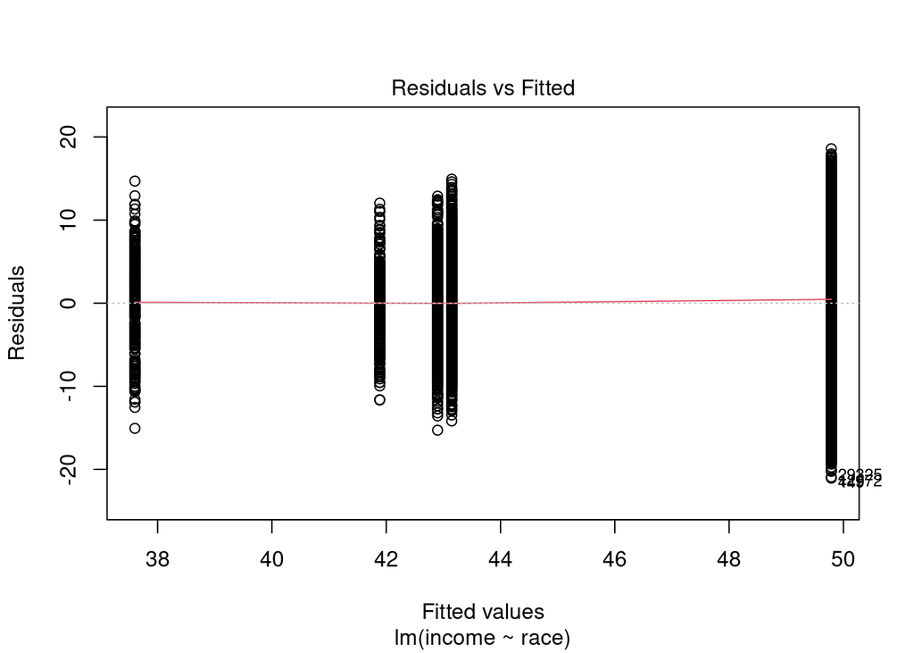

```r
plot(resultat_1, which = 1)
```

##### 6.2.6.2. Normalitat dels residus

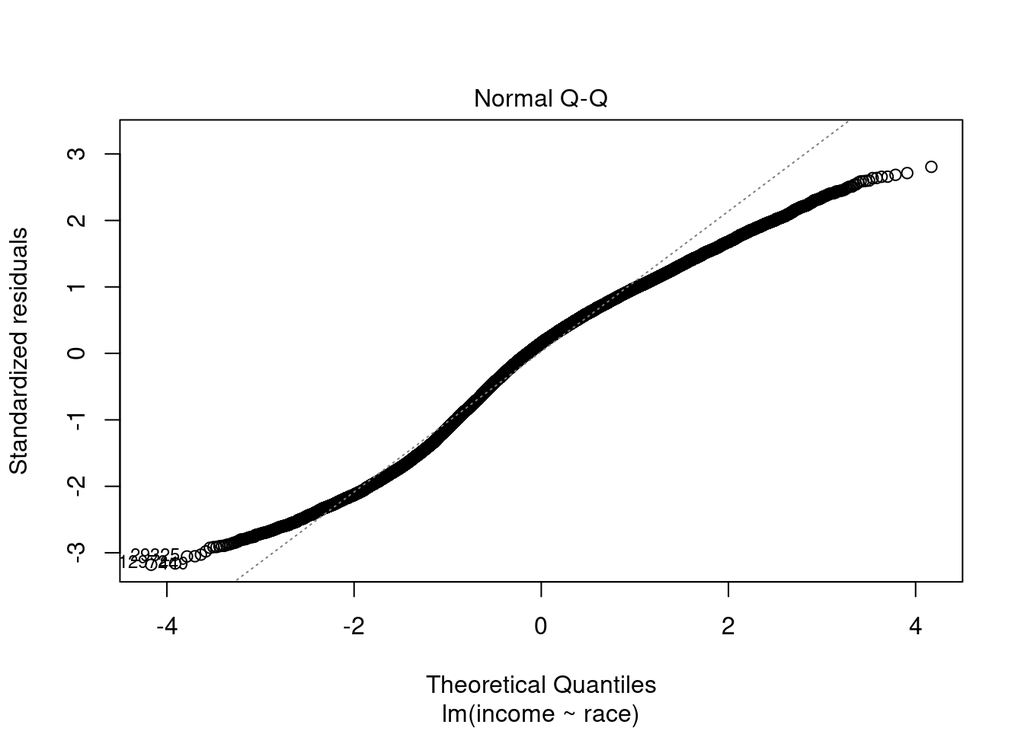

```r
plot(resultat_1, which = 2)
```

Sí que observem, en canvi, una desviació de la normalitat dels residus.

Seguidament, apliquem un test de Kruskal-Wallis, que no assumeix la normalitat de la distribució de les dades, i obtenim resultats que confirmen la diferència significativa entre grups:

```r
kruskal.test(income~race, data = adult)
```

```
##
##  Kruskal-Wallis rank sum test
##
## data:  income by race
## Kruskal-Wallis chi-squared = 4210.3, df = 4, p-value < 2.2e-16
```

## 7. ANOVA multifactorial

### 7.1. Estudi visual de la interacció

A la següent taula veiem que no tenim un escenari balancejat, ja que tenim un nombre diferent de mostres per a cada condició. El problema de treballar amb un escenari no balancejat és que, d’una banda, es redueix el poder estadístic de la prova, i de l’altra banda, l’estadístic de la prova és menys sensible a possibles desviacions de l’homocedasticitat.

```r
table(adult$race, adult$occupation)
```

```
##
##                      Blue-Collar Other/Unknown Professional Sales Service
##   White                     8714          1522         3651  3237    3962
##   Amer-Indian-Eskimo         120            26           33    26      45
##   Asian-Pac-Islander         215            65          186   108     191
##   Black                      909           216          239   254     772
##   Other                      104            23           31    25      51
##
##                      White-Collar
##   White                      6729
##   Amer-Indian-Eskimo           61
##   Asian-Pac-Islander          274
##   Black                       734
##   Other                        37
```

En el següent gràfic representem la interacció entre els factors raça i ocupació. A primera vista és difícil detectar si hi ha interacció:

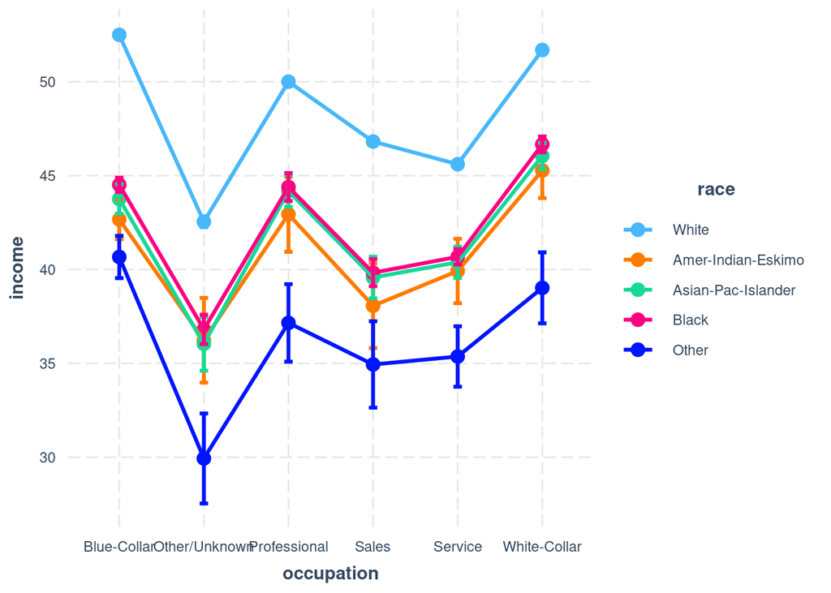

```r
library(ggplot2)
library(interactions)
inter <- lm(income~race*occupation, data = adult)
cat_plot(inter, pred=occupation, modx=race, geom='line')
```

En canvi, si ordenem els nivells de forma diferent, detectem un possible efecte d’interacció. Veiem, per exemple, que per les ocupacions ‘Blue-Collar’ i ‘Sales’, la distància entre la raça blanca i la resta és més gran. En general, mentre la línia de la raça blanca dibuixa un descens gradual a través dels diferents nivells del factor ocupació, les altres races dibuixen altibaixos:

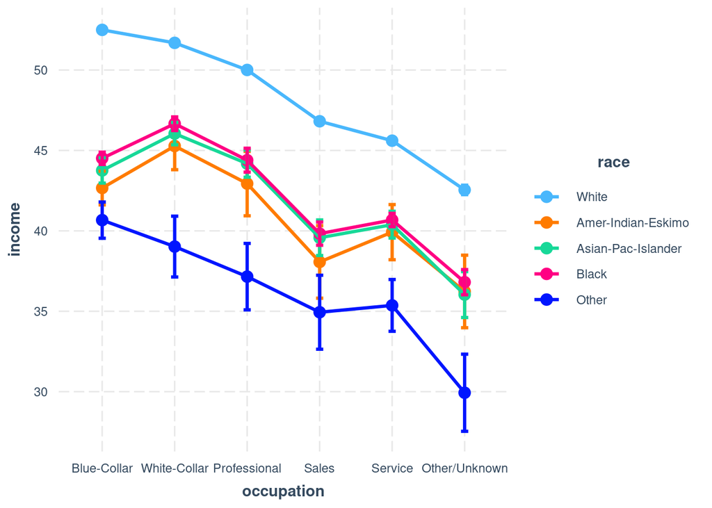

```r
adult$occupation <- factor(adult$occupation, levels = c('Blue-Collar', 'White-Collar', 'Professional', 'Sales', 'Service', 'Other/Unknown'))

library(ggplot2)
library(interactions)
inter <- lm(income~race*occupation, data = adult)
cat_plot(inter, pred=occupation, modx=race, geom='line')
```

## 8. Conclusions

Hem analitzat un conjunt de dades provinents d’un cens sobre els salaris i informació personal, amb un total de 32,560 registres i 9 variables.

Després de preparar les dades per a l’anàlisi, hem realitzat una anàlisi visual, amb la qual hem inicialment observat que entre els grups diferents que hi ha al conjunt, els salaris més alts els concentren els homes, les persones de raça blanca, els funcionaris de l’estat, les persones casades, els obrers (lleugerament per sobre d’administradors i treballadors del sector professional), les persones de més edat enfront de les joves, les persones que treballen més hores per setmana, i les persones amb més anys d’estudis.

Fent contrastos d’hipòtesis hem pogut comprovar que els homes cobren significativament més que les dones, i que les persones de raça blanca tenen un salari anual 6450€ per sobre del salari mitjà de les persones de raça negra.

Amb un model de regressió lineal hem pogut comprovar que les variables ‘edat’, ‘anys d’educació’, ‘hores setmanals treballades’, ‘gènere’ i ‘raça’ contribueixen conjuntament a explicar un 67% de la variància de la variable ‘salari anual’.

Amb un model de regressió logística, on hem analitzat la possibilitat que un individu cobri menys de 50,000€ anuals, hem observat que els factors que contribueixen a aquesta possibilitat són tenir menys edat, treballar menys hores, ser autònom, ser separat o solter, treballar en els sectors de vendes o serveis, ser dona, i ser de qualsevol altra raça que blanca.

Finalment, hem fet un estudi preliminar a un model d’anàlisi de variància multifactorial prenent les races i les ocupacions com a factors explicatius del salari. Hem trobat que no tenim un escenari balancejat per tal d’estimar aquest model de forma òptima, i també hem observat un lleuger efecte d’interacció entre les variables explicatives raça i ocupació.